# Fires Candice

candice

2022-11-23

## Exploratory

The distribution looks exponential or poisson, and ther might be an outlier after 10.

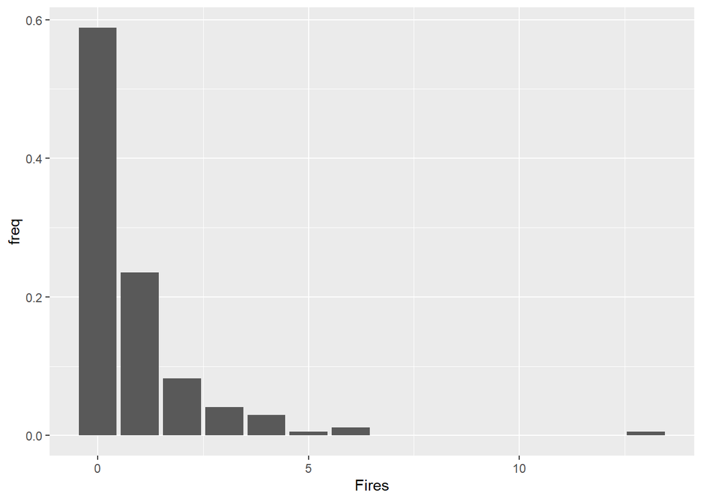

Who is the possible outlier ?

```
##     Direction Fires  Traffic       HGV Slope Urban          Type Length Limit
## 1 Direction 1    13 18180650 0.5114976 0.005    No Bidirectional  12868    70
##          SlopeType         Tunnel         Company
## 1 Continuous slope Cervus elaphus CERCOPITHECIDAE
```

[output not shown]

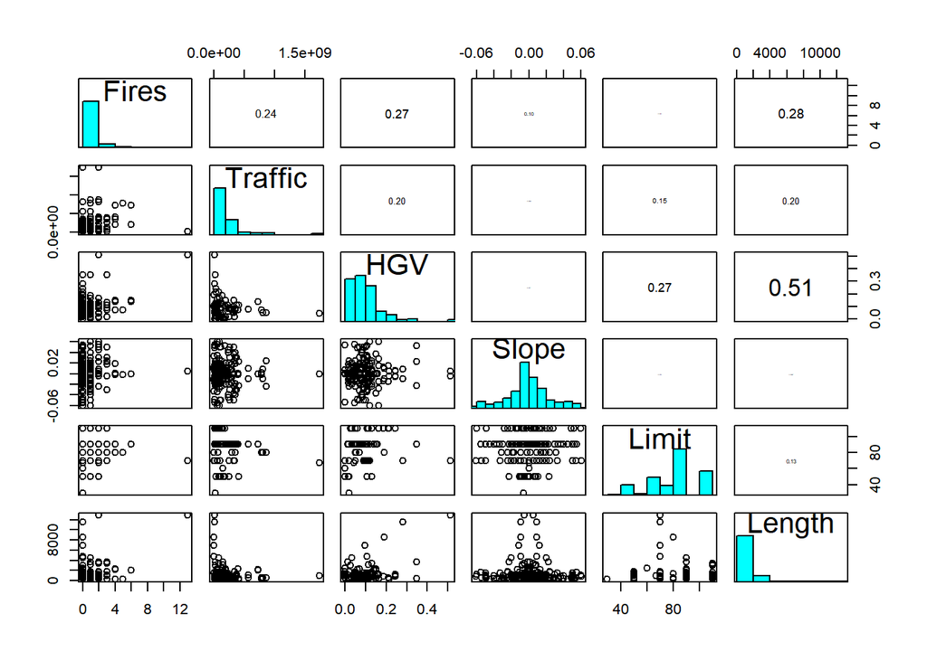

It looks like Fires are correlated with Traffic, HGV and Length. Length and HGV are correlated too so we should take this is account when we will try to fit the model.

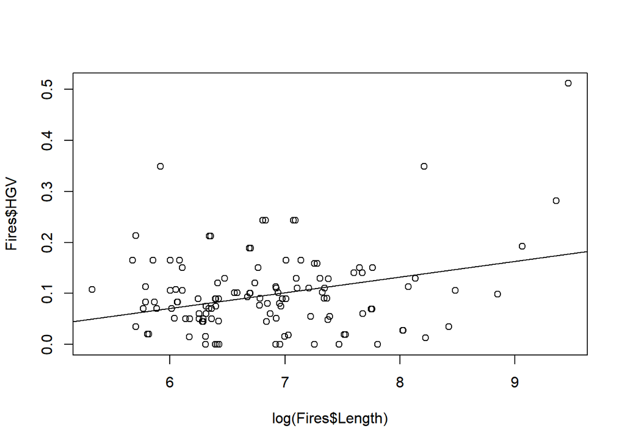

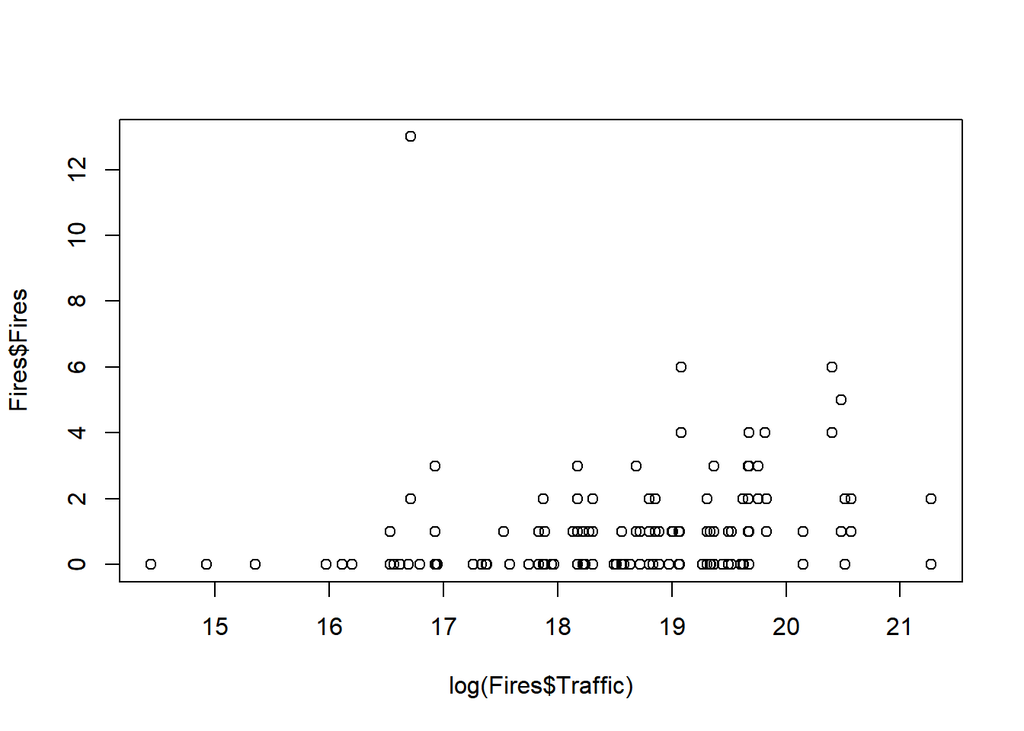

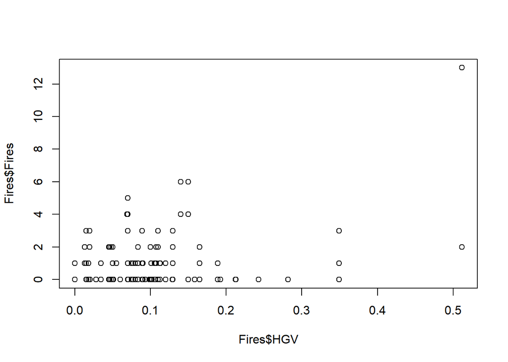

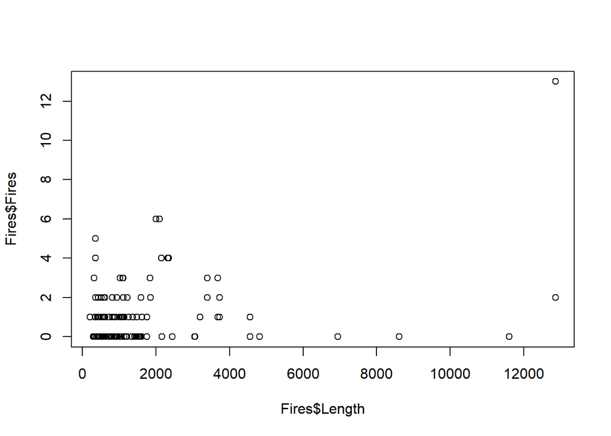

On papers I have read, they mention that Fires and Slope are significatively correlated, let’s see:

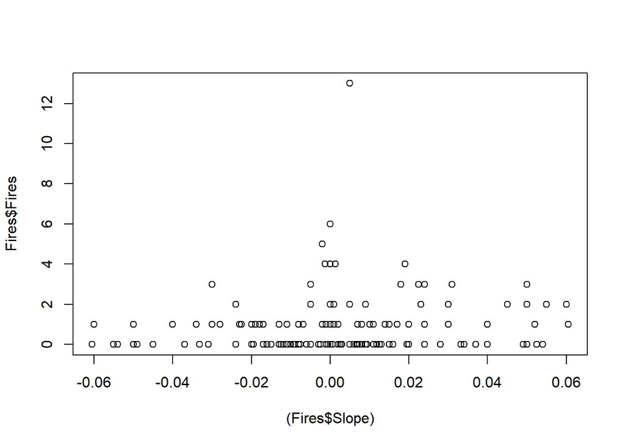

```r
plot((Fires$Slope), Fires$Fires)
```

```r
slope.lm <- lm(Fires~Slope, data=Fires)
summary(slope.lm)
```

```
##
## Call:
## lm(formula = Fires ~ Slope, data = Fires)
##
## Residuals:
##     Min      1Q  Median      3Q     Max
## -1.1596 -0.8248 -0.6879  0.2993 12.1538
##
## Coefficients:
##             Estimate Std. Error t value Pr(>|t|)
## (Intercept)   0.8142     0.1164   6.992  6.1e-11 ***
## Slope         6.3968     4.6940   1.363    0.175
## ---
## Signif. codes:  0 '***' 0.001 '**' 0.01 '*' 0.05 '.' 0.1 ' ' 1
##
## Residual standard error: 1.518 on 168 degrees of freedom
## Multiple R-squared:  0.01093,    Adjusted R-squared:  0.005046
## F-statistic: 1.857 on 1 and 168 DF,  p-value: 0.1748
```

The regression is clearly not significant as we might have expected from the graph.

## Regressions attempts

Traffic, HGV and Length seem to be significant.

```
##
## Call:
## lm(formula = Fires ~ Traffic + HGV + Slope + Urban + Type + Length +
##     Limit + SlopeType, data = Fires)
##
## Residuals:
##     Min      1Q  Median      3Q     Max
## -2.7637 -0.7201 -0.1976  0.4501  8.2253
##
## Coefficients:
##                             Estimate Std. Error t value Pr(>|t|)
## (Intercept)               -9.627e-01  8.438e-01  -1.141  0.25560
## Traffic                    1.227e-09  6.183e-10   1.984  0.04903 *
## HGV                        5.229e+00  1.761e+00   2.969  0.00345 **
## Slope                      6.521e+00  4.005e+00   1.628  0.10551
## UrbanYes                   5.515e-01  3.142e-01   1.755  0.08117 .
## TypeUnidirectional        -5.283e-02  3.238e-01  -0.163  0.87058
## Length                     2.155e-04  6.836e-05   3.152  0.00194 **
## Limit                      6.266e-03  7.090e-03   0.884  0.37815
## SlopeTypeBasin             1.024e+00  6.708e-01   1.526  0.12908
## SlopeTypeUnknown           8.420e-01  6.977e-01   1.207  0.22937
## SlopeTypeConstant slope    2.242e-02  1.026e+00   0.022  0.98259
## SlopeTypeContinuous slope -2.033e-01  6.185e-01  -0.329  0.74276
## SlopeTypeRoof             -7.652e-01  6.717e-01  -1.139  0.25638
## ---
## Signif. codes:  0 '***' 0.001 '**' 0.01 '*' 0.05 '.' 0.1 ' ' 1
##
## Residual standard error: 1.293 on 157 degrees of freedom
## Multiple R-squared:  0.3291, Adjusted R-squared:  0.2779
## F-statistic: 6.419 on 12 and 157 DF,  p-value: 3.25e-09
```

Doing the regression on only those 3 is in fact not that bad in terms of pvalue.

```
##
## Call:
## lm(formula = Fires ~ Traffic + HGV + Length, data = Fires)
##
## Residuals:
##     Min      1Q  Median      3Q     Max
## -3.6292 -0.7296 -0.2745  0.3198  8.9927
##
## Coefficients:
##               Estimate Std. Error t value Pr(>|t|)
## (Intercept) -2.357e-01  1.985e-01  -1.188  0.23672
## Traffic      2.042e-09  4.336e-10   4.710  5.2e-06 ***
## HGV          4.011e+00  1.501e+00   2.672  0.00828 **
## Length       1.674e-04  5.685e-05   2.945  0.00370 **
## ---
## Signif. codes:  0 '***' 0.001 '**' 0.01 '*' 0.05 '.' 0.1 ' ' 1
##
## Residual standard error: 1.367 on 166 degrees of freedom
## Multiple R-squared:  0.2078, Adjusted R-squared:  0.1935
## F-statistic: 14.52 on 3 and 166 DF,  p-value: 1.922e-08
```

Let’s look at the residuals. They are not normal at all (QQplot), there is no homoscedasticity, and we have some outliers.

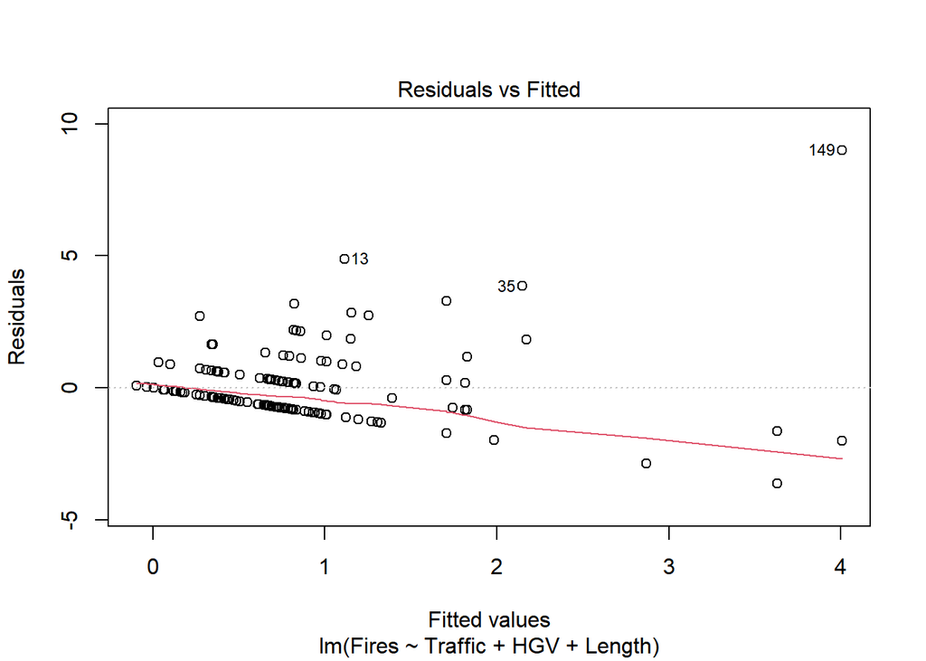

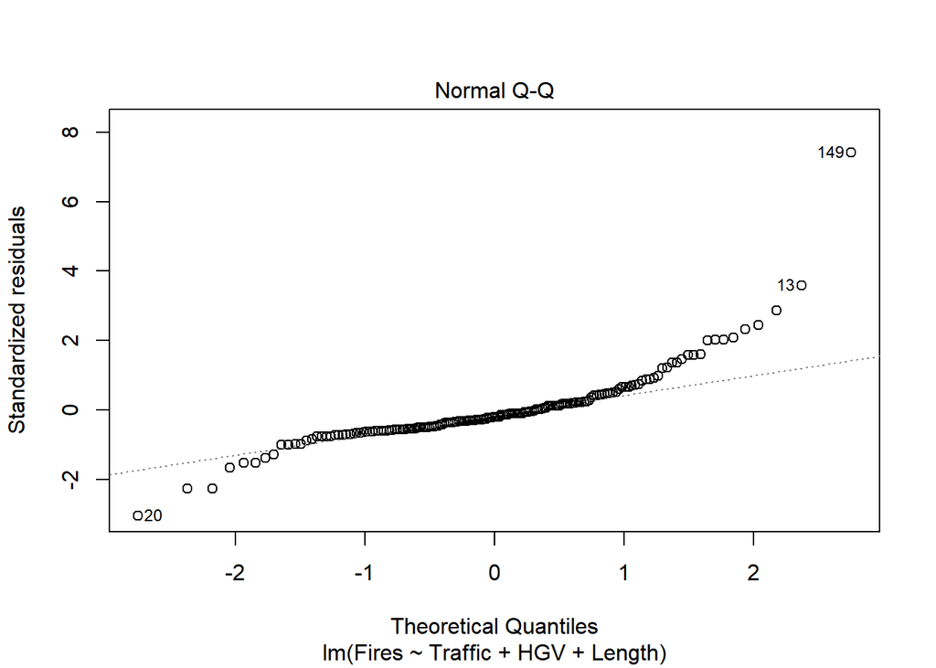

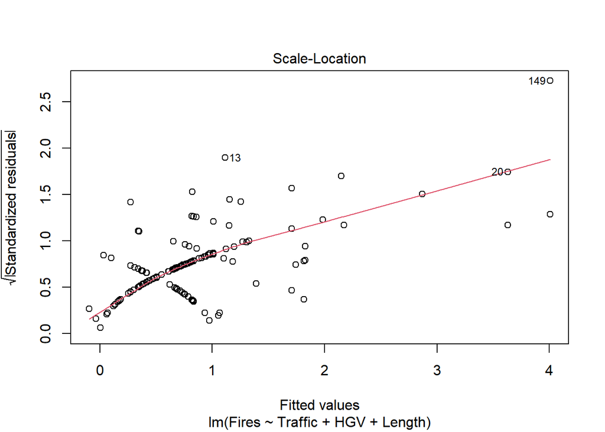

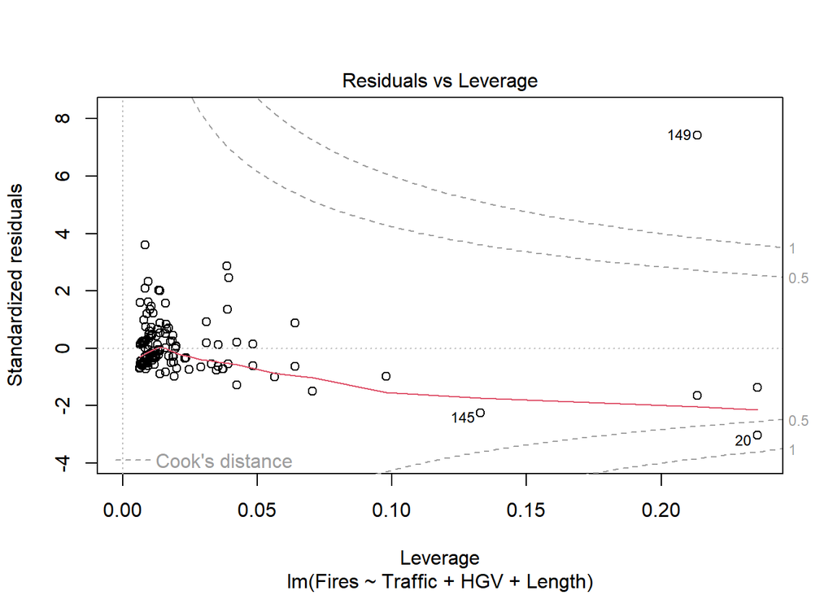

```
##
## Call:
## lm(formula = Fires ~ log(Traffic) + HGV + Length, data = Fires)
##
## Residuals:
##     Min      1Q  Median      3Q     Max
## -3.2664 -0.7373 -0.1209  0.5089  8.4098
##
## Coefficients:
##                Estimate Std. Error t value Pr(>|t|)
## (Intercept)  -1.019e+01  1.613e+00  -6.319 2.33e-09 ***
## log(Traffic)  5.539e-01  8.484e-02   6.529 7.73e-10 ***
## HGV           4.052e+00  1.422e+00   2.849  0.00494 **
## Length        2.683e-04  5.730e-05   4.682 5.87e-06 ***
## ---
## Signif. codes:  0 '***' 0.001 '**' 0.01 '*' 0.05 '.' 0.1 ' ' 1
##
## Residual standard error: 1.298 on 166 degrees of freedom
## Multiple R-squared:  0.2854, Adjusted R-squared:  0.2725
## F-statistic:  22.1 on 3 and 166 DF,  p-value: 4.298e-12
```

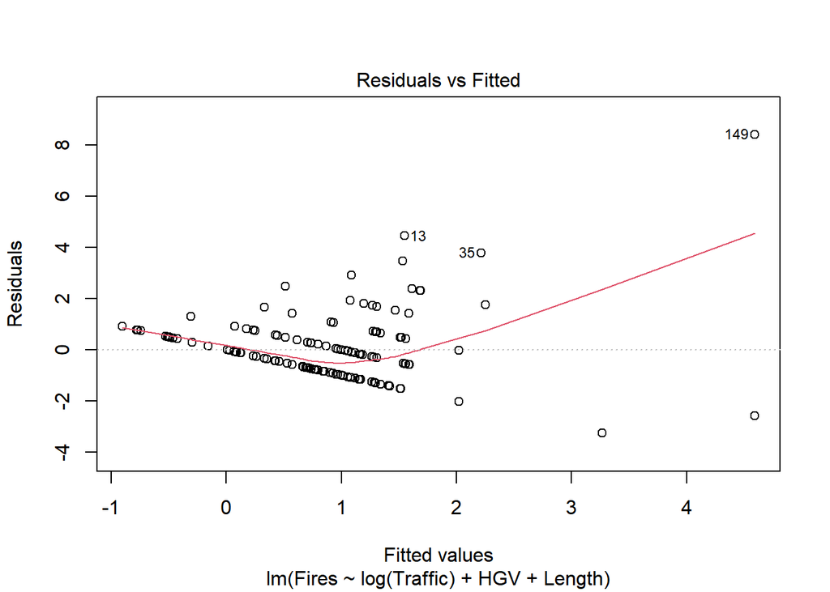

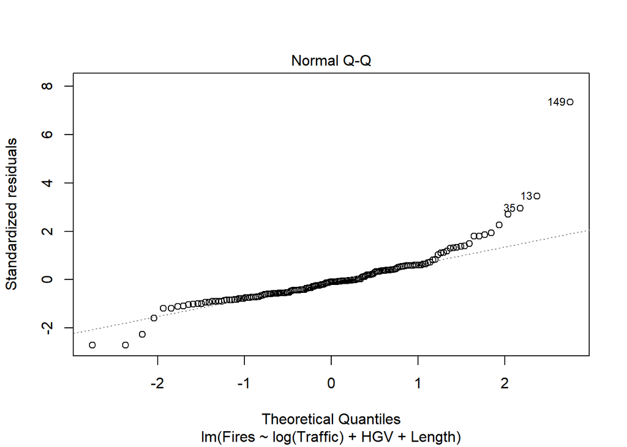

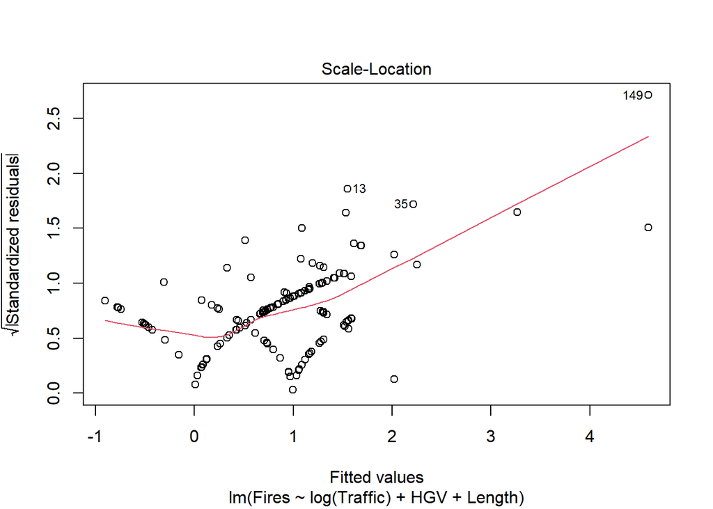

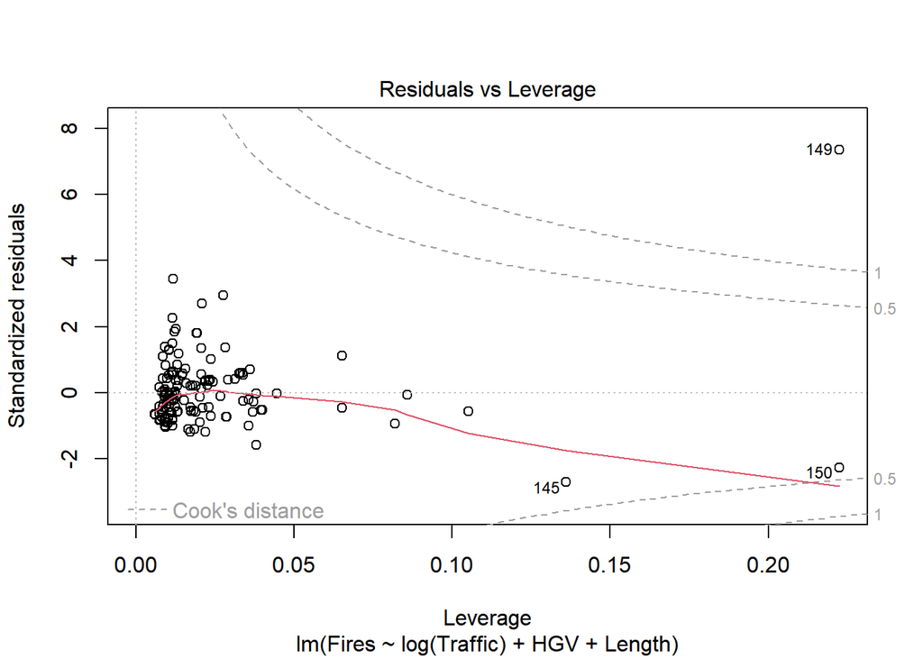

```
##
## Call:
## lm(formula = Fires ~ Traffic + HGV + log(Length), data = Fires)
##
## Residuals:
##     Min      1Q  Median      3Q     Max
## -3.6765 -0.7293 -0.2403  0.4107  9.4928
##
## Coefficients:
##               Estimate Std. Error t value Pr(>|t|)
## (Intercept) -2.754e+00  8.822e-01  -3.122 0.002119 **
## Traffic      2.051e-09  4.332e-10   4.734  4.7e-06 ***
## HGV          4.959e+00  1.367e+00   3.629 0.000379 ***
## log(Length)  3.897e-01  1.291e-01   3.019 0.002938 **
## ---
## Signif. codes:  0 '***' 0.001 '**' 0.01 '*' 0.05 '.' 0.1 ' ' 1
##
## Residual standard error: 1.365 on 166 degrees of freedom
## Multiple R-squared:  0.2098, Adjusted R-squared:  0.1956
## F-statistic: 14.69 on 3 and 166 DF,  p-value: 1.565e-08
```

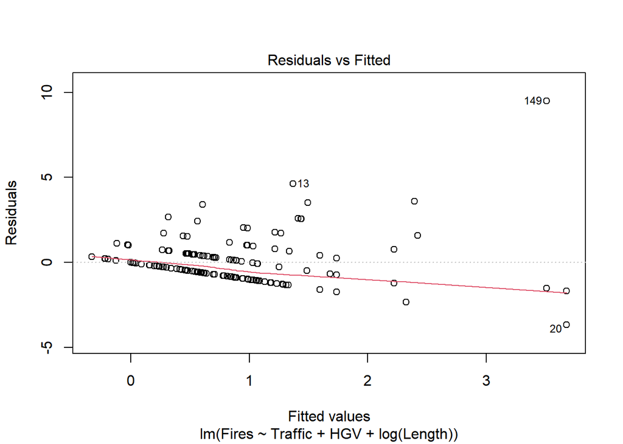

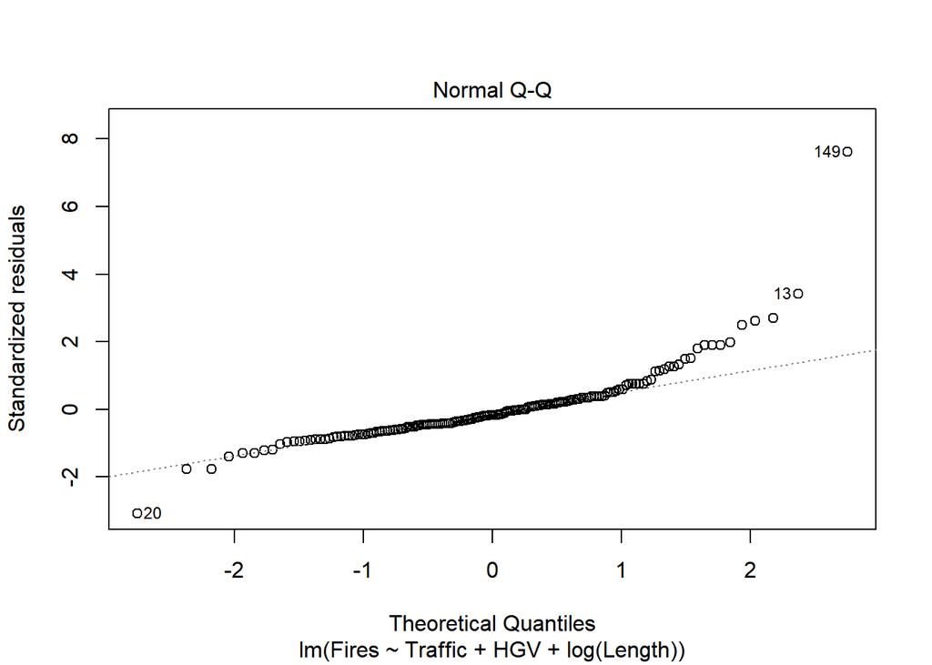

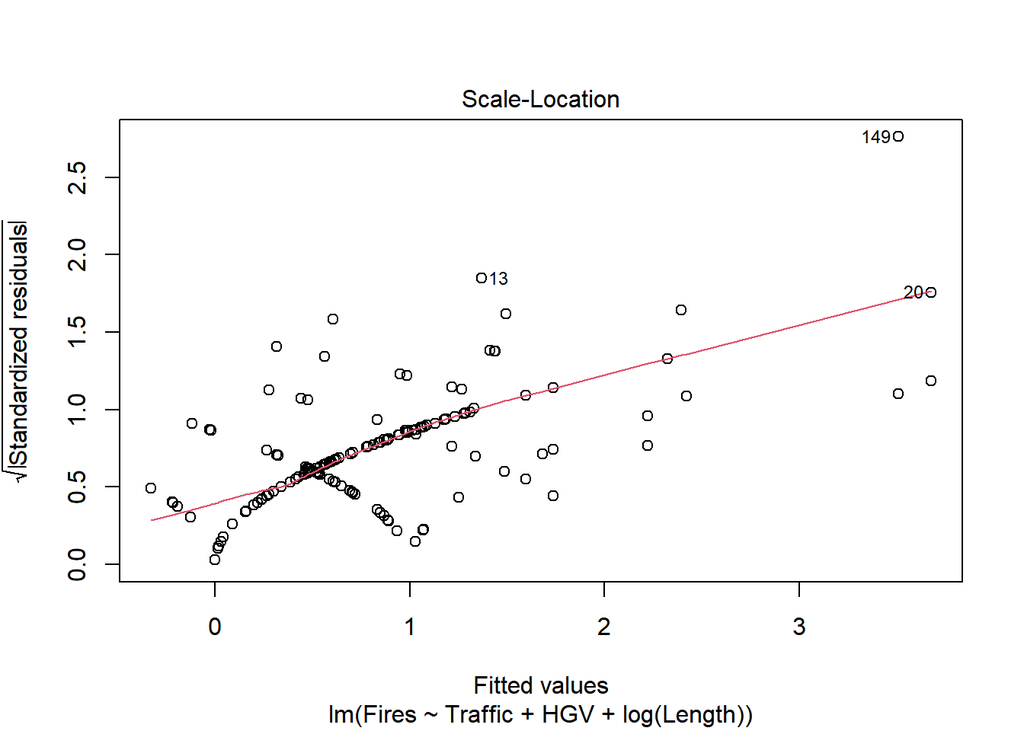

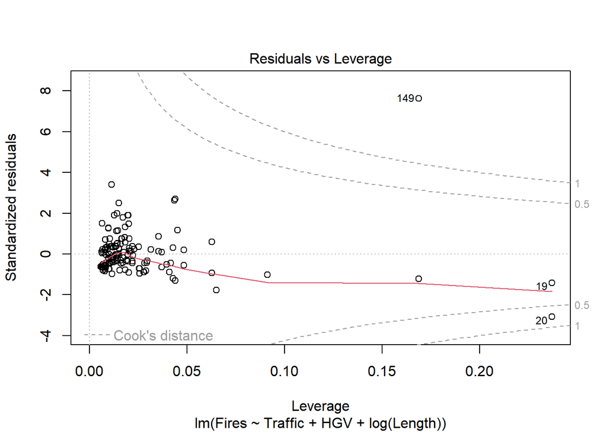

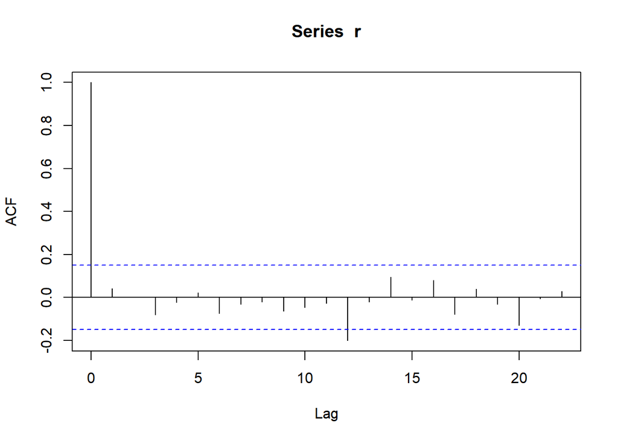

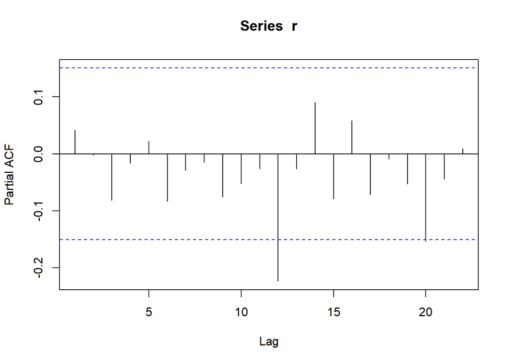

```r
Reg6 <- lm(HGV ~ Length, data = Fires)
summary(Reg6)
```

```
##
## Call:
## lm(formula = HGV ~ Length, data = Fires)
##
## Residuals:
##       Min        1Q    Median        3Q       Max
## -0.127068 -0.042239 -0.005679  0.030180  0.274060
##
## Coefficients:
##              Estimate Std. Error t value Pr(>|t|)
## (Intercept) 6.771e-02  6.711e-03  10.089  < 2e-16 ***
## Length      1.945e-05  2.508e-06   7.755 8.12e-13 ***
## ---
## Signif. codes:  0 '***' 0.001 '**' 0.01 '*' 0.05 '.' 0.1 ' ' 1
##
## Residual standard error: 0.07072 on 168 degrees of freedom
## Multiple R-squared:  0.2636, Adjusted R-squared:  0.2592
## F-statistic: 60.13 on 1 and 168 DF,  p-value: 8.119e-13
```

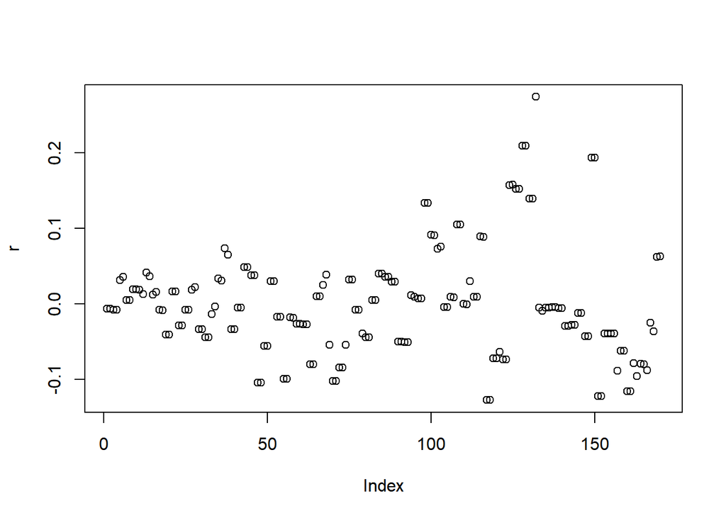

```r
r <- residuals(Reg6)
plot(r)
```